# Portfolio Part 4

Data set from: https://opendata.transport.nsw.gov.au/dataset/opal-trips-bus/resource/9862b4f1-37d9-495a-97b6-0c867fa91d83#%7B%7D

Description: Monthly Opal bus trips by contract area, month and card type, July 2016 to October 2021.

Questions / Challenges:

1. Are there seasonal changes between trends
2. View which Contract_Region / Trips that has the highest movement
3. What are the distribution rate of card types in NSW
4. Try different algoritm(s) to generate a model that is appropriate prediction of the chosen label

## 0. Import the Libraries

```python
#import Libraries First
import pandas as pd
import numpy as np
import matplotlib.pyplot as plt
import seaborn as sns
color_pal = sns.color_palette()
%matplotlib inline
from sklearn.preprocessing import OrdinalEncoder
from sklearn.neighbors import KNeighborsRegressor
from sklearn.model_selection import train_test_split, GridSearchCV
from sklearn.linear_model import LinearRegression
from sklearn.preprocessing import Normalizer
from sklearn.metrics import mean_absolute_error, mean_squared_error
from sklearn.metrics import confusion_matrix, accuracy_score, r2_score
from sklearn.metrics import roc_curve, auc
import xgboost as xgb
import warnings
warnings.filterwarnings('ignore')
```

## Exploratory Data Analysis

### 1.1 Load the dataset, check for null values, check the dimension of the dataframe.

Read the CSV and outout the intial 5 rows. As observed in our dataframe, the features are encoded in month-year format and the values in them are the number of trips.

```python
df = pd.read_csv('data/Bus_Card_Type.csv')
df.head(5)
```

|  | Contract_Type | Tap_Class | Jul-16 | Aug-16 | Sep-16 | Oct-16 | Nov-16 | Dec-16 | Jan-17 | Feb-17 | ... | Jan-21 | Feb-21 | Mar-21 | Apr-21 | May-21 | Jun-21 | Jul-21 | Aug-21 | Sep-21 | Oct-21 |
| --- | --- | --- | --- | --- | --- | --- | --- | --- | --- | --- | --- | --- | --- | --- | --- | --- | --- | --- | --- | --- | --- |
| 0 | Sydney Metro Bus Contract 1 | Adult | 390,433 | 386,386 | 370,068 | 381,402 | 405,245 | 353,196 | 341,332 | 386,683 | ... | 230,528 | 265,311 | 294,367 | 271,849 | 289,229 | 259,924 | 127,354 | 102,937 | 104,623 | 160,054 |
| 1 | Sydney Metro Bus Contract 1 | Adult Single Bus Trip 1 | NaN | 25,753 | 23,416 | 23,138 | 23,352 | 22,065 | 21,306 | 21,277 | ... | 3 | 3 | 10 | 4 | 8 | 8 | 7 | 6 | 2 | 3 |
| 2 | Sydney Metro Bus Contract 1 | Adult Single Bus Trip 2 | NaN | 17,882 | 14,984 | 14,465 | 13,914 | 13,285 | 12,021 | 11,824 | ... | NaN | NaN | 1 | 7 | 2 | 4 | 1 | 4 | NaN | NaN |
| 3 | Sydney Metro Bus Contract 1 | Adult Single Bus Trip 3 | NaN | 1,880 | 1,459 | 1,355 | 1,198 | 1,102 | 1,098 | 1,009 | ... | NaN | 3 | NaN | NaN | NaN | 4 | NaN | 2 | NaN | NaN |
| 4 | Sydney Metro Bus Contract 1 | Child/Youth | 62,800 | 67,010 | 70,022 | 78,951 | 76,328 | 77,290 | 80,779 | 80,920 | ... | 46,574 | 45,469 | 42,069 | 52,658 | 42,457 | 34,715 | 11,205 | 6,725 | 9,170 | 24,293 |

5 rows × 66 columns

Using tail, we noticed that there is a grand total row for each month-year. We can remove that to further clean our dataframe.

```python
df.tail(3)
```

|  | Contract_Type | Tap_Class | Jul-16 | Aug-16 | Sep-16 | Oct-16 | Nov-16 | Dec-16 | Jan-17 | Feb-17 | ... | Jan-21 | Feb-21 | Mar-21 | Apr-21 | May-21 | Jun-21 | Jul-21 | Aug-21 | Sep-21 | Oct-21 |
| --- | --- | --- | --- | --- | --- | --- | --- | --- | --- | --- | --- | --- | --- | --- | --- | --- | --- | --- | --- | --- | --- |
| 610 | Outer Sydney Metro Bus Contract 5 | School Student | 45,224 | 110,239 | 75,262 | 71,065 | 92,417 | 33,800 | 5,512 | 91,284 | ... | NaN | NaN | NaN | NaN | NaN | NaN | NaN | NaN | NaN | NaN |
| 611 | Outer Sydney Metro Bus Contract 5 | Senior/Pensioner | 124,570 | 139,526 | 137,657 | 134,642 | 143,341 | 135,737 | 127,356 | 131,825 | ... | NaN | NaN | NaN | NaN | NaN | NaN | NaN | NaN | NaN | NaN |
| 612 | Grand Total | Total | 21,198,509 | 25,210,772 | 23,011,540 | 23,095,302 | 24,422,383 | 20,880,865 | 19,550,895 | 22,534,683 | ... | 11,567,325 | 14,964,876 | 17,032,074 | 15,471,111 | 16,650,452 | 13,859,329 | 5,106,594 | 4,287,197 | 4,655,971 | 8,392,219 |

3 rows × 66 columns

Using the drop method, we can remove the last row in our dataframe.

```python
df = df.drop(index=df.index[-1], axis=0)
df.tail(3)
```

|  | Contract_Type | Tap_Class | Jul-16 | Aug-16 | Sep-16 | Oct-16 | Nov-16 | Dec-16 | Jan-17 | Feb-17 | ... | Jan-21 | Feb-21 | Mar-21 | Apr-21 | May-21 | Jun-21 | Jul-21 | Aug-21 | Sep-21 | Oct-21 |
| --- | --- | --- | --- | --- | --- | --- | --- | --- | --- | --- | --- | --- | --- | --- | --- | --- | --- | --- | --- | --- | --- |
| 609 | Outer Sydney Metro Bus Contract 5 | Free Travel | 957 | 1,162 | 1,061 | 1,063 | 1,215 | 1,388 | 1,309 | 1,127 | ... | NaN | NaN | NaN | NaN | NaN | NaN | NaN | NaN | NaN | NaN |
| 610 | Outer Sydney Metro Bus Contract 5 | School Student | 45,224 | 110,239 | 75,262 | 71,065 | 92,417 | 33,800 | 5,512 | 91,284 | ... | NaN | NaN | NaN | NaN | NaN | NaN | NaN | NaN | NaN | NaN |
| 611 | Outer Sydney Metro Bus Contract 5 | Senior/Pensioner | 124,570 | 139,526 | 137,657 | 134,642 | 143,341 | 135,737 | 127,356 | 131,825 | ... | NaN | NaN | NaN | NaN | NaN | NaN | NaN | NaN | NaN | NaN |

3 rows × 66 columns

The cell below will check to see the null values in our dataframe.

```python
busCardDF = df.copy()
busCardDF.info()
```

```
<class 'pandas.core.frame.DataFrame'>
RangeIndex: 612 entries, 0 to 611
Data columns (total 66 columns):
 #   Column         Non-Null Count  Dtype
---  ------         --------------  -----
 0   Contract_Type  612 non-null    object
 1   Tap_Class      612 non-null    object
 2   Jul-16         227 non-null    object
 3   Aug-16         456 non-null    object
 4   Sep-16         451 non-null    object
 5   Oct-16         454 non-null    object
 6   Nov-16         448 non-null    object
 7   Dec-16         454 non-null    object
 8   Jan-17         450 non-null    object
 9   Feb-17         454 non-null    object
```

[output cut: 58 more lines]

Check the nulls in our dataframe.

```python
busCardDF.isnull().sum()
```

```
Contract_Type      0
Tap_Class          0
Jul-16           385
Aug-16           156
Sep-16           161
                ...
Jun-21           338
Jul-21           338
Aug-21           341
Sep-21           353
Oct-21           320
Length: 66, dtype: int64
```

Check the total records that has nulls value

```python
busCardDF.isnull().sum().sum()
```

```
15650
```

There are 15,650 null values in our dataframe. If we remove them per row, some of the values that has initial filled in records in some features will be completely gone. So here, we could probably modify our dataframe and instead of making features with the month-year, we'll make it as a value instead. So the dataframe would be like these:

a. Contract_Type  
b. Tap_Class  
c. Date *(In year month format)*  
d. Taps_Count

```python
tempBusCardDF = busCardDF.copy()
```

We would have the data wrangling method here where we will transform our dataframe into more readable and easier to understand to our algorithm, and for us.

```python
import datetime

wrangDF = pd.DataFrame(columns=['Contract_Type', 'Tap_Class', 'Year', 'Month', 'Day', 'Taps_Count'])
for index, row in tempBusCardDF.iterrows():
    colCount = 0
    columnNames = []
    for column in tempBusCardDF.loc[[index]]:
        # print(tempBusCardDF.loc[[index]][column].values)
        colCount+=1
        columnNames.append(tempBusCardDF.loc[[index]][column].values)
        if colCount > 2:
            _date = column.split("-")
            _month = _date[0]

            ##Convert the month to number
            month_name = _month
            datetime_object = datetime.datetime.strptime(month_name, "%b")
            _month = datetime_object.month

            _year = int(_date[1]) + 2000

            taps = tempBusCardDF.loc[[index]][column].values[0]
            if  isinstance(taps, float):
                taps = 0
                pass
            else:
                taps = taps.replace(',','')
                taps = int(taps)
                newRow = {'Contract_Type' : columnNames[0][0], 'Tap_Class':columnNames[1][0], 'Year': _year, 'Month':  _month, 'Day': 1, 'Taps_Count': taps}
                wrangDF = wrangDF.append(newRow, ignore_index=True)
```

Below is our new dataframe, we'll use this dataframe until the end of this pipeline.

```python
wrangDF.tail(5)
```

|  | Contract_Type | Tap_Class | Year | Month | Day | Taps_Count |
| --- | --- | --- | --- | --- | --- | --- |
| 23513 | Outer Sydney Metro Bus Contract 5 | Senior/Pensioner | 2017 | 3 | 1 | 149897 |
| 23514 | Outer Sydney Metro Bus Contract 5 | Senior/Pensioner | 2017 | 4 | 1 | 125352 |
| 23515 | Outer Sydney Metro Bus Contract 5 | Senior/Pensioner | 2017 | 5 | 1 | 144478 |
| 23516 | Outer Sydney Metro Bus Contract 5 | Senior/Pensioner | 2017 | 6 | 1 | 130625 |
| 23517 | Outer Sydney Metro Bus Contract 5 | Senior/Pensioner | 2017 | 7 | 1 | 11 |

So far the converted data looks good. Let's try to export the csv for future use.

```python
wrangDF.to_csv("data/Bus_Card_Type_Converted.csv")
```

As we created a new dataframe, it is important to check the data-type of our columns.

```python
wrangDF.dtypes
```

```
Contract_Type    object
Tap_Class        object
Year             object
Month            object
Day              object
Taps_Count       object
dtype: object
```

### 1.2 Generate graphs to quickly compare against the taps per year, months, class and contracts.

```python
#Converte the types of each column
wrangDF.Taps_Count = wrangDF.Taps_Count.astype('int64')
wrangDF.Year = wrangDF.Year.astype('int64')
wrangDF.Month = wrangDF.Month.astype('int64')
wrangDF.Day = wrangDF.Day.astype('int64')
```

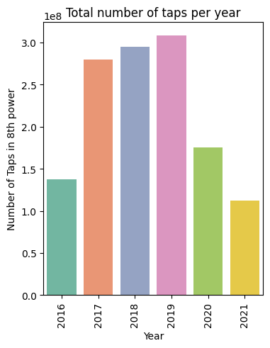

```python
yearDistribution = wrangDF.groupby(['Year'], as_index=False).sum()

sns.set_palette("Set2")
plt.figure(figsize=(4,5))
plt.xticks(rotation=90)
sns.barplot(data=yearDistribution, x="Year", y="Taps_Count")
plt.title('Total number of taps per year')
plt.xlabel('Year')
plt.ylabel('Number of Taps in 8th power')
```

Check the average taps below, there is a dip of movement in 2017. The reason for this is some of the trips got lesser movement or taps in the same month on 2016, and some of the lines stopped their operation.

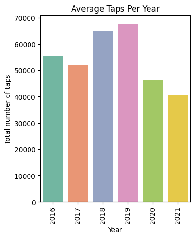

```python
yearDistribution = wrangDF.groupby(['Year'], as_index=False).mean()

sns.set_palette("Set2")
plt.figure(figsize=(4,5))
plt.xticks(rotation=90)
sns.barplot(data=yearDistribution, x="Year", y="Taps_Count")
plt.title('Average Taps Per Year')
plt.xlabel('Year')
plt.ylabel('Total number of taps')
```

As seen, the month of March got the highest movement. This can be attributed to the several festivals happening in the city.

The low activity in January, April and December can be attributed to the session break of the universities, the holidays in public schools.

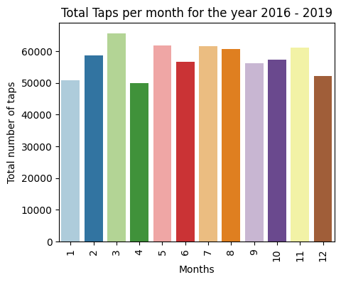

```python
monthDistribution = wrangDF[wrangDF["Year"] < 2021].groupby('Month', as_index=False).mean()

sns.set_palette("Paired")
plt.figure(figsize=(5,4))
plt.xticks(rotation=90)
sns.barplot(data=monthDistribution, x="Month", y="Taps_Count")
plt.title('Total Taps per month for the year 2016 - 2019')
plt.xlabel('Months')
plt.ylabel('Total number of taps')
```

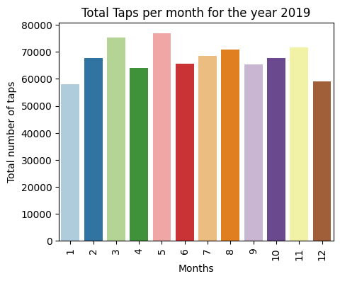

```python
monthDistribution2019 = wrangDF[wrangDF["Year"] == 2019].groupby('Month', as_index=False).mean()

sns.set_palette("Paired")
plt.figure(figsize=(5,4))
plt.xticks(rotation=90)
sns.barplot(data=monthDistribution2019, x="Month", y="Taps_Count")
plt.title('Total Taps per month for the year 2019')
plt.xlabel('Months')
plt.ylabel('Total number of taps')
```

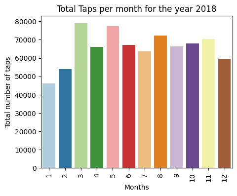

```python
monthDistribution2018 = wrangDF[wrangDF["Year"] == 2018].groupby('Month', as_index=False).mean()

sns.set_palette("Paired")
plt.figure(figsize=(5,4))
plt.xticks(rotation=90)
sns.barplot(data=monthDistribution2018, x="Month", y="Taps_Count")
plt.title('Total Taps per month for the year 2018')
plt.xlabel('Months')
plt.ylabel('Total number of taps')
```

Noticed that in the graph below, there was a big hit in number of transactions / tap in April. The reason could be of the lock down imposed by the NSW government.

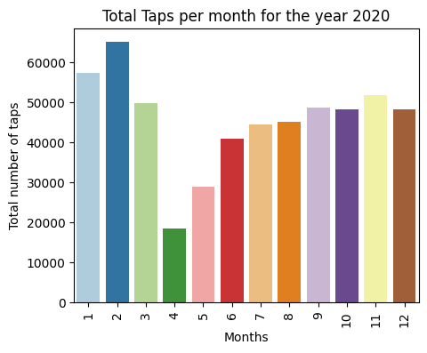

```python
monthDistribution2020 = wrangDF[wrangDF["Year"] == 2020].groupby('Month', as_index=False).mean()

sns.set_palette("Paired")
plt.figure(figsize=(5,4))
plt.xticks(rotation=90)
sns.barplot(data=monthDistribution2020, x="Month", y="Taps_Count")
plt.title('Total Taps per month for the year 2020')
plt.xlabel('Months')
plt.ylabel('Total number of taps')
```

To see the trendline, we'll use the lineplot from sns. See the figure below for comparison. 2018 and 2019 almost has the same trend line. 2020 got the big hit.

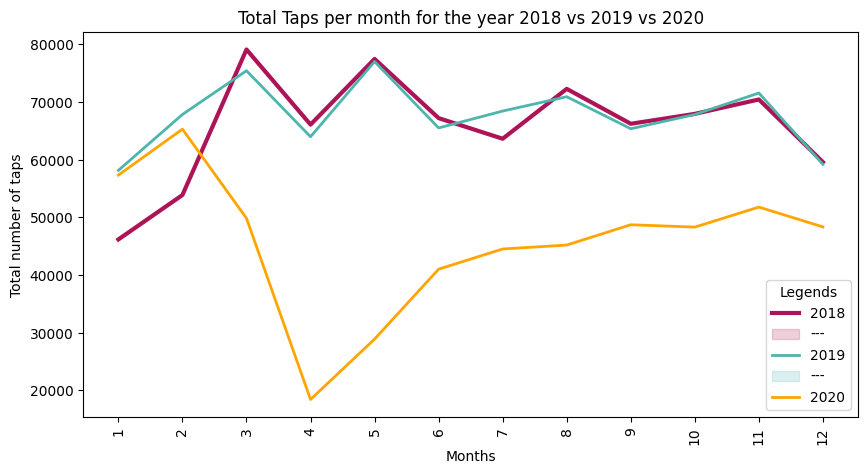

```python
sns.set_palette("Paired")
plt.figure(figsize=(10,5))
plt.xticks([1,2,3,4,5,6,7,8,9,10,11,12], rotation=90)
sns.lineplot(data=monthDistribution2018, x="Month", y="Taps_Count", linewidth=3, color="#AD1457")
sns.lineplot(data=monthDistribution2019, x="Month", y="Taps_Count", linewidth=2, color="#4DB6AC")
sns.lineplot(data=monthDistribution2020, x="Month", y="Taps_Count", linewidth=2, color="orange")
plt.title('Total Taps per month for the year 2018 vs 2019 vs 2020')
plt.legend(title='Legends', loc='lower right', labels=['2018','---', '2019', '---', '2020'])
plt.xlabel('Months')
plt.ylabel('Total number of taps')
```

Based on the statistics, https://www.abs.gov.au/articles/snapshot-nsw-2021 , there are 20.4 million living in NSW right now. 9.4M of which are below 18. Suffice to say, the graph below looks relatively right.

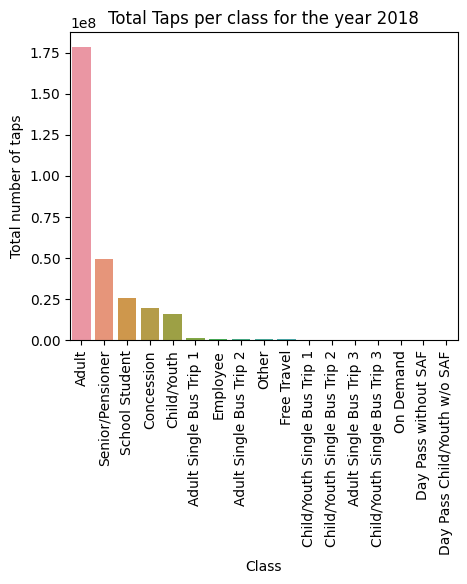

```python
tapClass2018 = wrangDF[wrangDF['Year'] == 2018].groupby(['Tap_Class'], as_index=False).sum()
tapClass2018 = tapClass2018.sort_values('Taps_Count', ascending=False)

sns.set_palette("Paired")
plt.figure(figsize=(5,4))
plt.xticks(rotation=90)
sns.barplot(data=tapClass2018, x="Tap_Class", y="Taps_Count")
plt.title('Total Taps per class for the year 2018')
plt.xlabel('Class')
plt.ylabel('Total number of taps')
```

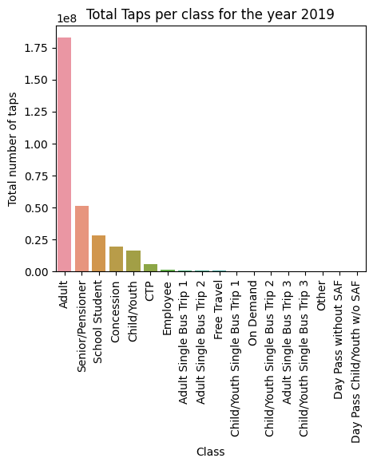

```python
tapClass2019 = wrangDF[wrangDF['Year'] == 2019].groupby(['Tap_Class'], as_index=False).sum().sort_values('Taps_Count', ascending=False)

sns.set_palette("Paired")
plt.figure(figsize=(5,4))
plt.xticks(rotation=90)
sns.barplot(data=tapClass2019, x="Tap_Class", y="Taps_Count")
plt.title('Total Taps per class for the year 2019')
plt.xlabel('Class')
plt.ylabel('Total number of taps')
```

There is an increase of movement for the CTP in the year 2020

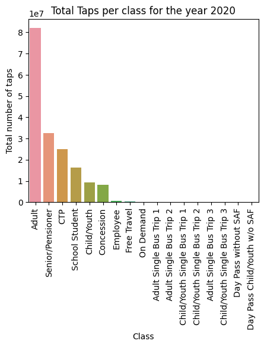

```python
tapClass2020 = wrangDF[wrangDF['Year'] == 2020].groupby(['Tap_Class'], as_index=False).sum().sort_values('Taps_Count', ascending=False)

sns.set_palette("Paired")
plt.figure(figsize=(5,4))
plt.xticks(rotation=90)
sns.barplot(data=tapClass2020, x="Tap_Class", y="Taps_Count")
plt.title('Total Taps per class for the year 2020')
plt.xlabel('Class')
plt.ylabel('Total number of taps')
```

Looking in our graph below, we can say the same that there was a mejor decline in transaction during the 2020.

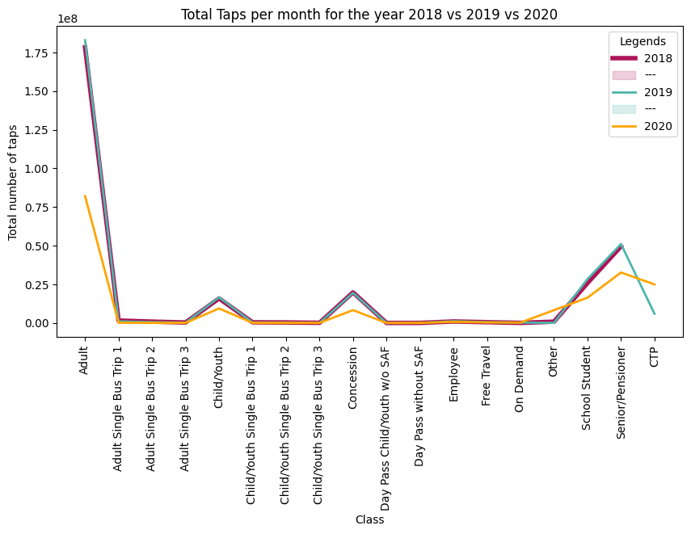

```python
tapClass2018 = tapClass2018.sort_values('Tap_Class')
tapClass2019 = tapClass2019.sort_values('Tap_Class')
tapClass2020 = tapClass2020.sort_values('Tap_Class')

sns.set_palette("Paired")
plt.figure(figsize=(10,5))
plt.xticks(rotation=90)
sns.lineplot(data=tapClass2018, x="Tap_Class", y="Taps_Count", linewidth=4, color="#AD1457")
sns.lineplot(data=tapClass2019, x="Tap_Class", y="Taps_Count", linewidth=2, color="#4DB6AC")
sns.lineplot(data=tapClass2020, x="Tap_Class", y="Taps_Count", linewidth=2, color="orange")
plt.title('Total Taps per month for the year 2018 vs 2019 vs 2020')
plt.legend(title='Legends', loc='upper right', labels=['2018','---', '2019', '---', '2020'])
plt.xlabel('Class')
plt.ylabel('Total number of taps')
```

Sydney Metro Bus was the popular choice for mode of transportation. It just make sense as it connects to almost major sub urb in NSW.

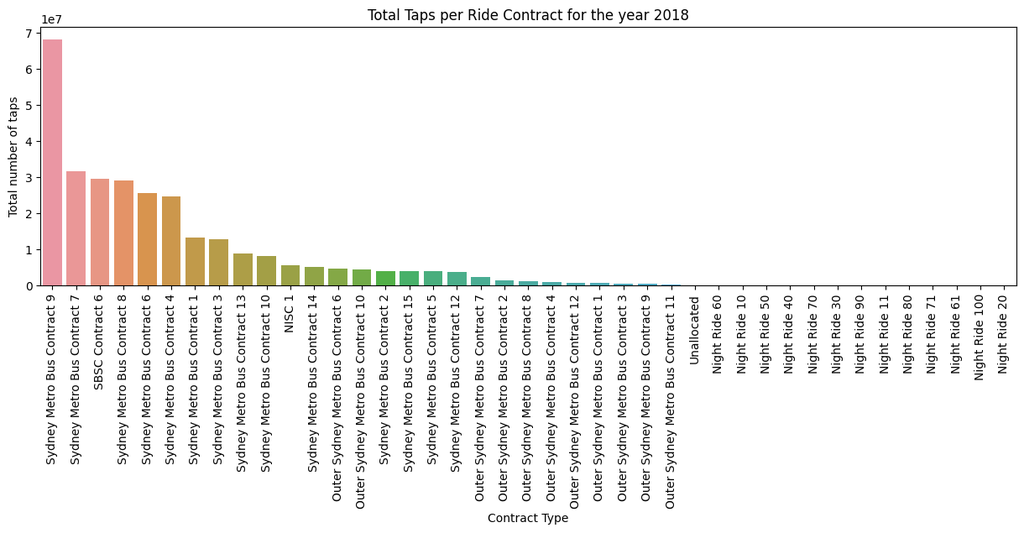

```python
contract2018 = wrangDF[wrangDF["Year"] == 2018].groupby(['Contract_Type'], as_index=False).sum().sort_values('Taps_Count', ascending=False)

sns.set_palette("Paired")
plt.figure(figsize=(15,4))
plt.xticks(rotation=90)
sns.barplot(data=contract2018, x="Contract_Type", y="Taps_Count")
plt.title('Total Taps per Ride Contract for the year 2018')
plt.xlabel('Contract Type')
plt.ylabel('Total number of taps')
```

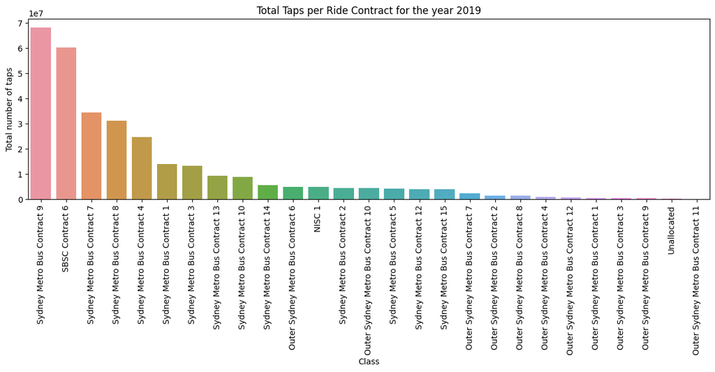

```python
contract2019 = wrangDF[wrangDF["Year"] == 2019].groupby(['Contract_Type'], as_index=False).sum().sort_values('Taps_Count', ascending=False)

sns.set_palette("Paired")
plt.figure(figsize=(15,4))
plt.xticks(rotation=90)
sns.barplot(data=contract2019, x="Contract_Type", y="Taps_Count")
plt.title('Total Taps per Ride Contract for the year 2019')
plt.xlabel('Class')
plt.ylabel('Total number of taps')
```

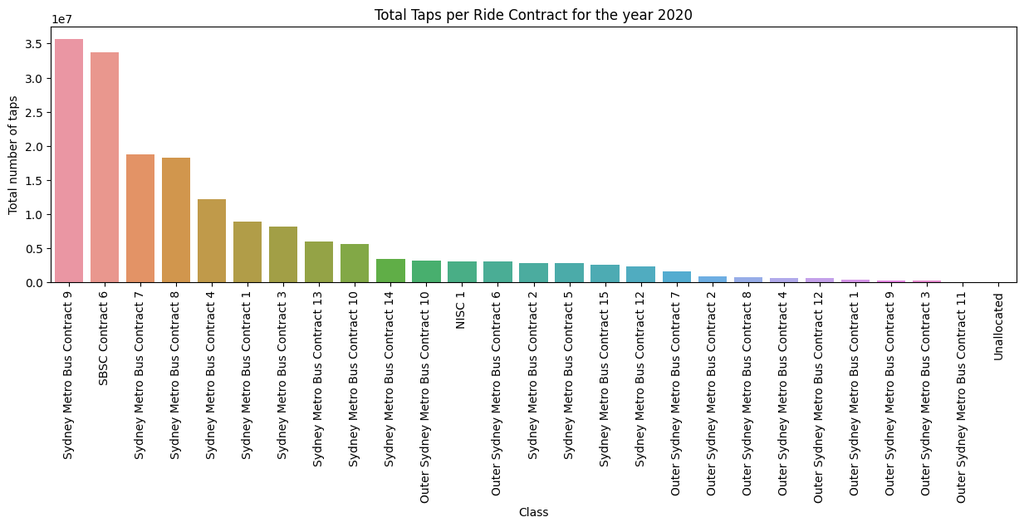

```python
contract2020 = wrangDF[wrangDF["Year"] == 2020].groupby(['Contract_Type'], as_index=False).sum().sort_values('Taps_Count', ascending=False)

sns.set_palette("Paired")
plt.figure(figsize=(15,4))
plt.xticks(rotation=90)
sns.barplot(data=contract2020, x="Contract_Type", y="Taps_Count")
plt.title('Total Taps per Ride Contract for the year 2020')
plt.xlabel('Class')
plt.ylabel('Total number of taps')
```

With the trend line, we can see that there is major hit during the 2020.

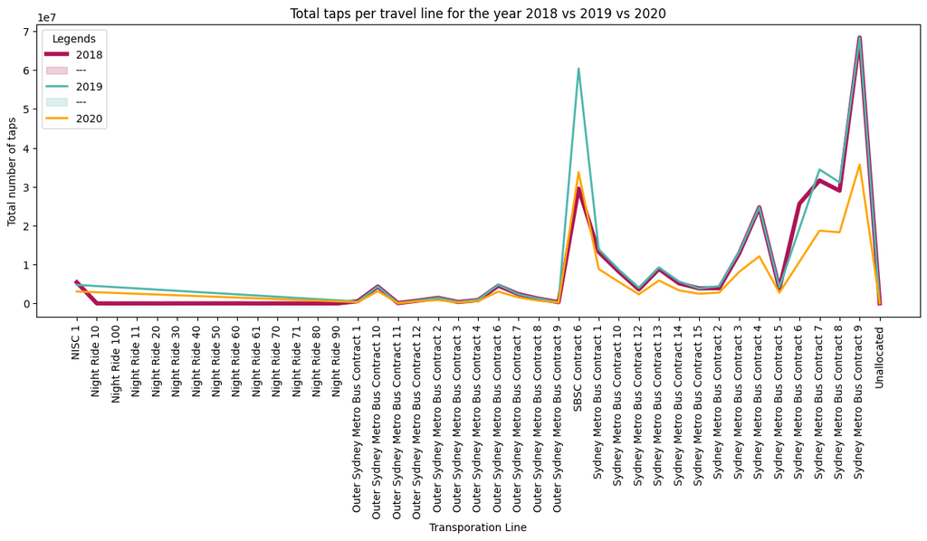

```python
contract2018 = contract2018.sort_values('Contract_Type')
contract2019 = contract2019.sort_values('Contract_Type')
contract2020 = contract2020.sort_values('Contract_Type')

sns.set_palette("Paired")
plt.figure(figsize=(15,5))
plt.xticks(rotation=90)
sns.lineplot(data=contract2018, x="Contract_Type", y="Taps_Count", linewidth=4, color="#AD1457")
sns.lineplot(data=contract2019, x="Contract_Type", y="Taps_Count", linewidth=2, color="#4DB6AC")
sns.lineplot(data=contract2020, x="Contract_Type", y="Taps_Count", linewidth=2, color="orange")
plt.title('Total taps per travel line for the year 2018 vs 2019 vs 2020')
plt.legend(title='Legends', loc='upper left', labels=['2018','---', '2019', '---', '2020'])
plt.xlabel('Transporation Line')
plt.ylabel('Total number of taps')
```

### 1.3 Transform the values of each row into an encoded order, check correlation and distribution.

```python
enc = OrdinalEncoder()
encodedWrangDF = wrangDF.copy()
encodedWrangDF[["Contract_Type","Tap_Class"]] = enc.fit_transform(encodedWrangDF[["Contract_Type","Tap_Class"]])
```

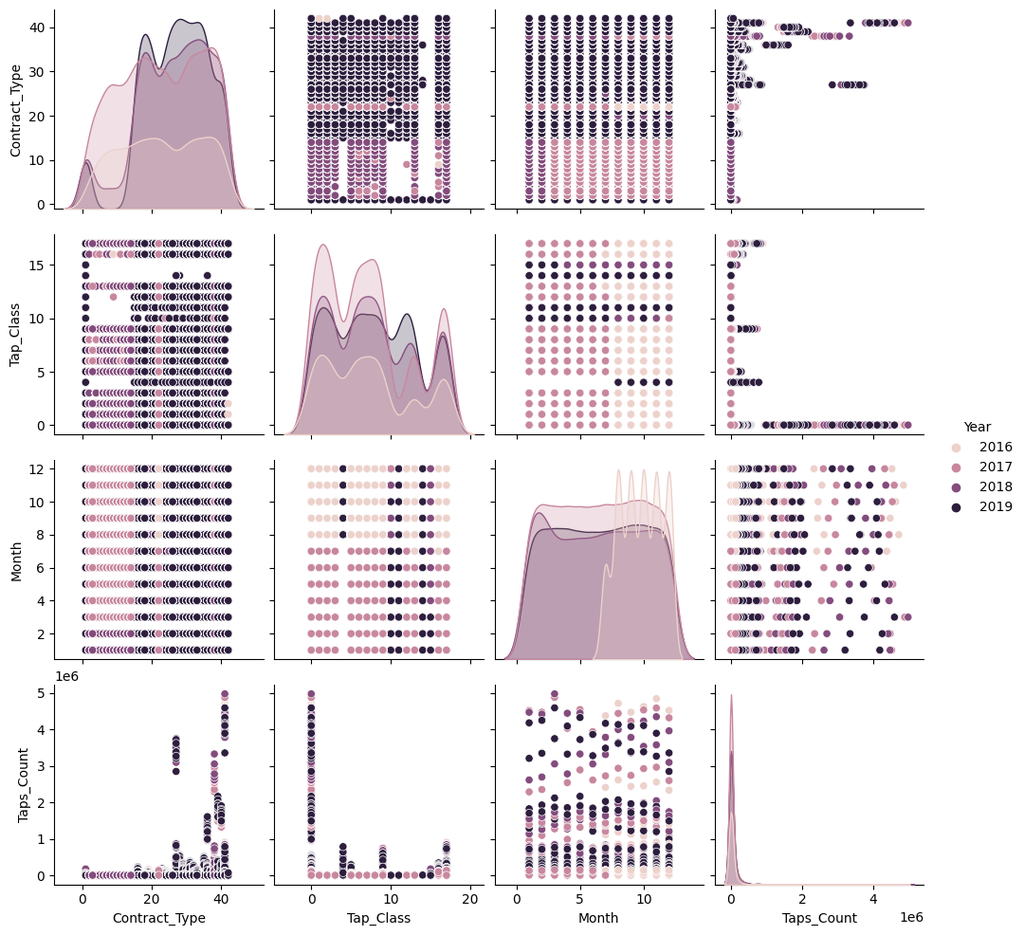

```python
#Exluding 2020 and 2021 as these are pandemic season.
sns.pairplot(data=encodedWrangDF[encodedWrangDF["Year"]<2020].drop(columns=['Day']), hue="Year")
```

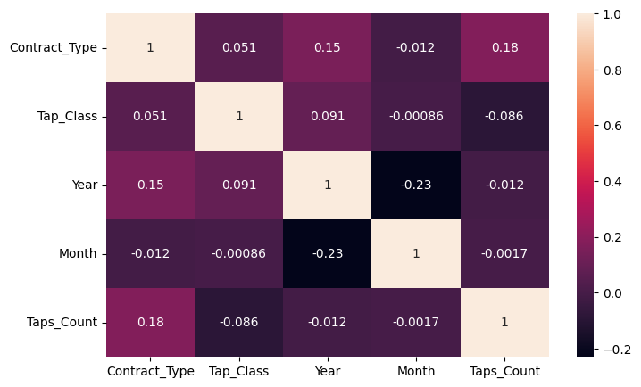

```python
plt.figure(figsize=(8,5))
sns.heatmap(encodedWrangDF.drop(columns=['Day']).corr(),annot=True)
```

### 1.4 plot the dataframe using datetime column

```python
tempWrangDF = encodedWrangDF[encodedWrangDF['Year'] < 2020].copy()
tempWrangDF['Date'] = pd.to_datetime(tempWrangDF[['Year', 'Month', 'Day']])
tempWrangDF = tempWrangDF.sort_values('Date', ascending=True)
```

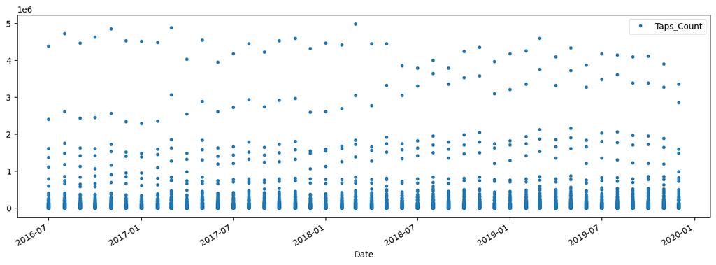

```python
tempWrangDF.plot(style='.',
    x="Date",
    y="Taps_Count",
    color=color_pal[0],
    figsize=(15, 5))
```

#### 1.5 Normalize the dataframe

```python
from sklearn import preprocessing
scaler = preprocessing.MinMaxScaler(feature_range=(1, 100))

taps_count = tempWrangDF['Taps_Count'].values
taps_count = taps_count.reshape(-1, 1)
x_scaled = scaler.fit_transform(taps_count)
tempWrangDF.Taps_Count = x_scaled
```

```python
tempWrangDF.head()
```

|  | Contract_Type | Tap_Class | Year | Month | Day | Taps_Count | Date |
| --- | --- | --- | --- | --- | --- | --- | --- |
| 0 | 28.0 | 0.0 | 2016 | 7 | 1 | 8.769178 | 2016-07-01 |
| 16876 | 25.0 | 0.0 | 2016 | 7 | 1 | 1.622158 | 2016-07-01 |
| 4977 | 39.0 | 0.0 | 2016 | 7 | 1 | 33.149223 | 2016-07-01 |
| 16739 | 24.0 | 17.0 | 2016 | 7 | 1 | 2.057466 | 2016-07-01 |
| 16675 | 24.0 | 16.0 | 2016 | 7 | 1 | 1.945893 | 2016-07-01 |

## 2 Train / Test Split

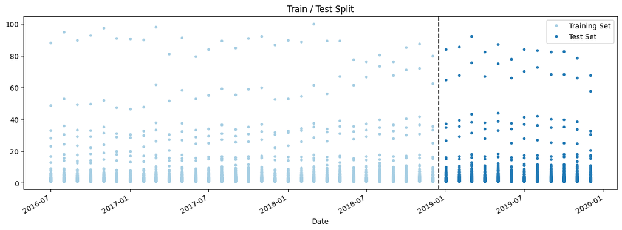

```python
train = tempWrangDF.loc[tempWrangDF.Date < '2019-01-01']
test = tempWrangDF.loc[tempWrangDF.Date >= '2019-01-01']

fig, ax = plt.subplots(figsize=(15, 5))
train.plot(ax=ax, x="Date", y="Taps_Count", label="Training Set", style='.', title="Train / Test Split")
test.plot(ax=ax, x="Date", y="Taps_Count", label="Test Set", style='.')
ax.axvline('2018-12-15', color="black", ls="--")
plt.show()
```

## 3.1 Create the model - XGBOOST

```python
features = ['Contract_Type', 'Tap_Class', 'Year', 'Month']
target = 'Taps_Count'
```

```python
X_train = train[features]
y_train = train[target]

X_test = test[features]
y_test = test[target]
```

```python
reg = xgb.XGBRegressor(n_estimators = 10000, early_stopping_rounds=50, learning_rate = 0.001)
reg.fit(X_train,
    y_train,
    eval_set=[(X_train, y_train), (X_test, y_test)],
    verbose=500)
```

```
XGBRegressor(base_score=0.5, booster='gbtree', callbacks=None,
             colsample_bylevel=1, colsample_bynode=1, colsample_bytree=1,
             early_stopping_rounds=50, enable_categorical=False,
             eval_metric=None, gamma=0, gpu_id=-1, grow_policy='depthwise',
             importance_type=None, interaction_constraints='',
             learning_rate=0.001, max_bin=256, max_cat_to_onehot=4,
             max_delta_step=0, max_depth=6, max_leaves=0, min_child_weight=1,
             missing=nan, monotone_constraints='()', n_estimators=10000,
             n_jobs=0, num_parallel_tree=1, predictor='auto', random_state=0,
             reg_alpha=0, reg_lambda=1, ...)
```

#### 3.1.1 Feature Importance

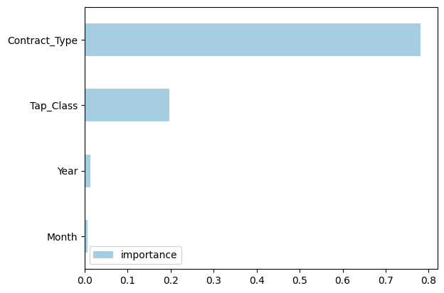

```python
fi = pd.DataFrame(data=reg.feature_importances_, index=reg.feature_names_in_, columns=['importance'])
fi.sort_values('importance').plot(kind="barh")
plt.show()
```

#### 3.1.2 Forecast on Test

```python
test['prediction'] = reg.predict(X_test)
tempWrangDF = tempWrangDF.merge(test[['prediction']], how='left', left_index=True, right_index=True)
```

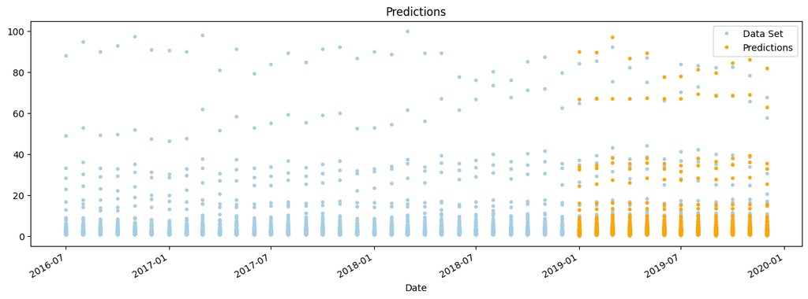

```python
fig, ax = plt.subplots(figsize=(15, 5))
tempWrangDF.plot(ax=ax, x="Date", y="Taps_Count", label="Data Set", style='.', title="Predictions")
tempWrangDF.plot(ax=ax, x="Date", y="prediction", label="Predictions", style='.', color="orange")
plt.show()
```

```python
score = np.sqrt(mean_squared_error(test['Taps_Count'], test['prediction']))
score
```

```
0.7222387237925278
```

```python
# Evaluation
maeLog = mean_absolute_error(y_test, test['prediction'])
mseLog = mean_squared_error(y_test, test['prediction'])
rmseLog = np.sqrt(mean_squared_error(y_test, test['prediction']))
r2Log = r2_score(y_test, test['prediction'])

#Metric Logs
print('Metric Logs')
print(f'Mean absolute error: {maeLog:.3f}')
print(f'Mean squared error: {mseLog:.3f}')
print(f'Root mean squared error: {rmseLog:.2f}')
print(f'Adjusted R-Squared: {r2Log:.3f}')
```

```
Metric Logs
Mean absolute error: 0.245
Mean squared error: 0.522
Root mean squared error: 0.72
Adjusted R-Squared: 0.987
```

### 3.1.3 Create a dictionary to compare the Root Mean Square Error and some metrics

```python
metrics_data = dict({'ModelName': ['XGBRegressor'], 'MAE': [maeLog], 'MSE': [mseLog], 'RMSE': [rmseLog], 'AdjustedRSquared':[r2Log]})
test_results = {}
test_results['XGBRegressor'] = np.sqrt(mean_squared_error(y_test, test['prediction']))
```

```python
test['error'] = np.abs(test[target] - test['prediction'])
test.sort_values('error', ascending=True).head(10)
```

|  | Contract_Type | Tap_Class | Year | Month | Day | Taps_Count | Date | prediction | error |
| --- | --- | --- | --- | --- | --- | --- | --- | --- | --- |
| 13839 | 21.0 | 1.0 | 2019 | 5 | 1 | 1.030883 | 2019-05-01 | 1.030903 | 0.000020 |
| 12367 | 19.0 | 3.0 | 2019 | 10 | 1 | 1.013193 | 2019-10-01 | 1.013246 | 0.000053 |
| 12532 | 19.0 | 7.0 | 2019 | 9 | 1 | 1.005930 | 2019-09-01 | 1.005857 | 0.000073 |
| 12423 | 19.0 | 5.0 | 2019 | 12 | 1 | 1.147968 | 2019-12-01 | 1.148043 | 0.000075 |
| 14253 | 21.0 | 12.0 | 2019 | 2 | 1 | 1.002069 | 2019-02-01 | 1.001985 | 0.000085 |
| 12859 | 19.0 | 17.0 | 2019 | 9 | 1 | 1.554303 | 2019-09-01 | 1.554434 | 0.000131 |
| 15798 | 23.0 | 12.0 | 2019 | 1 | 1 | 1.023321 | 2019-01-01 | 1.023488 | 0.000166 |
| 9793 | 31.0 | 11.0 | 2019 | 2 | 1 | 1.000298 | 2019-02-01 | 1.000468 | 0.000169 |
| 2438 | 35.0 | 11.0 | 2019 | 12 | 1 | 1.001075 | 2019-12-01 | 1.000905 | 0.000170 |
| 14173 | 21.0 | 8.0 | 2019 | 9 | 1 | 1.002388 | 2019-09-01 | 1.002185 | 0.000203 |

## 3.2 Create the model - Linear Regression

```python
reg = LinearRegression()
regModel = reg.fit(X_train, y_train)
logModelPrediction = regModel.predict(X_test)
```

```python
# check actual and predicted scores
dfPreds = pd.DataFrame({'Actual': y_test.squeeze(), 'Predicted': logModelPrediction.squeeze()})
dfPreds.head()
```

|  | Actual | Predicted |
| --- | --- | --- |
| 2898 | 3.148183 | 3.137136 |
| 3741 | 1.248875 | 3.241419 |
| 549 | 1.040594 | 1.918643 |
| 2014 | 1.070800 | 3.224964 |
| 989 | 1.045210 | 3.600962 |

```python
# Evaluation
maeLog = mean_absolute_error(y_test, logModelPrediction)
mseLog = mean_squared_error(y_test, logModelPrediction)
rmseLog = np.sqrt(mean_squared_error(y_test, logModelPrediction))
r2Log = r2_score(y_test, logModelPrediction)

#Metric Logs
print('Metric Logs')
print(f'Mean absolute error: {maeLog:.3f}')
print(f'Mean squared error: {mseLog:.3f}')
print(f'Root mean squared error: {rmseLog:.2f}')
print(f'Adjusted R-Squared: {r2Log:.3f}')

test_results['LinearRegression'] = np.sqrt(mean_squared_error(y_test, logModelPrediction))

#Metrics Data

metrics_data['ModelName'].append('LinearRegression')
metrics_data['MAE'].append(maeLog)
metrics_data['MSE'].append(mseLog)
metrics_data['RMSE'].append(rmseLog)
metrics_data['AdjustedRSquared'].append(r2Log)
```

```
Metric Logs
Mean absolute error: 2.118
Mean squared error: 39.024
Root mean squared error: 6.25
Adjusted R-Squared: 0.035
```

## 3.3 Create the model - Neural Network Regression and Deep Neural Network Regression

```python
import matplotlib.pyplot as plt
import numpy as np
import pandas as pd
import seaborn as sns

# Make NumPy printouts easier to read.
np.set_printoptions(precision=3, suppress=True)

import tensorflow as tf

from tensorflow import keras
from tensorflow.keras import layers

print(tf.__version__)
```

[output not shown]

```
No supported GPU was found.
2.10.0
```

### 3.3.1 Preparing the dataset

```python
train_dataset = encodedWrangDF.loc[encodedWrangDF.Year < 2019]
test_dataset = encodedWrangDF.loc[encodedWrangDF.Year == 2019]
```

```python
transformer = Normalizer()
```

```python
train_features = train_dataset.drop(columns=['Taps_Count']).copy()
test_features = test_dataset.drop(columns=['Taps_Count']).copy()

train_labels = train_dataset.drop(columns=['Contract_Type', 'Tap_Class', 'Year', 'Day','Month'])
test_labels = test_dataset.drop(columns=['Contract_Type', 'Tap_Class', 'Year', 'Day','Month'])

train_labels.Taps_Count = transformer.transform(train_labels[['Taps_Count']])
test_labels.Taps_Count = transformer.transform(test_labels[['Taps_Count']])
```

```python
normalizer = tf.keras.layers.Normalization(axis=-1)
normalizer.adapt(np.array(train_features))
```

[output not shown]

```python
def plot_loss(history, _label):
  label = _label
  plt.plot(history.history['loss'], label='loss')
  plt.plot(history.history['val_loss'], label='val_loss')
  plt.xlabel('Epoch')
  plt.ylabel(label)
  plt.legend()
  plt.grid(True)
```

### 3.3.2 Linear Regression Neural Network with multiple inputs

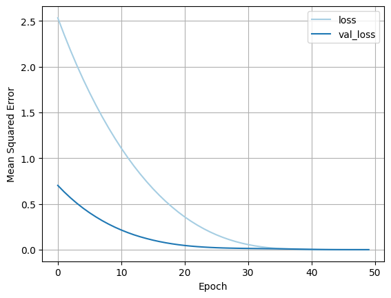

```python
linear_model = tf.keras.Sequential([
    normalizer,
    layers.Dense(units=1)
])

linear_model.compile(
    optimizer=tf.keras.optimizers.Adam(learning_rate=0.0001),
    loss='mean_squared_error')

lin_model = linear_model.fit(
    train_features,
    train_labels['Taps_Count'],
    epochs=50,
    # Suppress logging.
    verbose=0,
    # Calculate validation results on 20% of the training data.
    validation_split = 0.2)

test_results['linear_neural_network'] = np.sqrt(linear_model.evaluate(test_features, test_labels['Taps_Count'], verbose=0))
test_results

metrics_data['ModelName'].append('Linear_Neural_Networ')
metrics_data['MSE'].append(linear_model.evaluate(test_features, test_labels['Taps_Count'], verbose=0))
metrics_data['RMSE'].append(np.sqrt(linear_model.evaluate(test_features, test_labels['Taps_Count'], verbose=0)))


plot_loss(lin_model, 'Mean Squared Error')
```

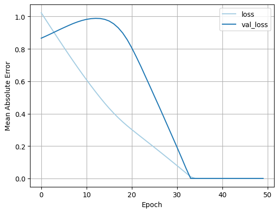

```python
##Mean Absolute Error
linear_model = tf.keras.Sequential([
    normalizer,
    layers.Dense(units=1)
])

linear_model.compile(
    optimizer=tf.keras.optimizers.Adam(learning_rate=0.0001),
    loss='mean_absolute_error')

lin_model = linear_model.fit(
    train_features,
    train_labels['Taps_Count'],
    epochs=50,
    # Suppress logging.
    verbose=0,
    # Calculate validation results on 20% of the training data.
    validation_split = 0.2)

metrics_data['MAE'].append(linear_model.evaluate(test_features, test_labels['Taps_Count'], verbose=0))
metrics_data['AdjustedRSquared'].append(0)

plot_loss(lin_model, 'Mean Absolute Error')
```

### 3.3.3 Regression using a DNN and multiple inputs

```
Model: "sequential_2"
_________________________________________________________________
 Layer (type)                Output Shape              Param #
=================================================================
 normalization (Normalizatio  (None, 5)                11
 n)

 dense_2 (Dense)             (None, 32)                192

 dense_3 (Dense)             (None, 64)                2112

 dense_4 (Dense)             (None, 128)               8320

 dense_5 (Dense)             (None, 64)                8256

 dense_6 (Dense)             (None, 32)                2080

 dense_7 (Dense)             (None, 1)                 33

=================================================================
Total params: 21,004
Trainable params: 20,993
Non-trainable params: 11
_________________________________________________________________
```

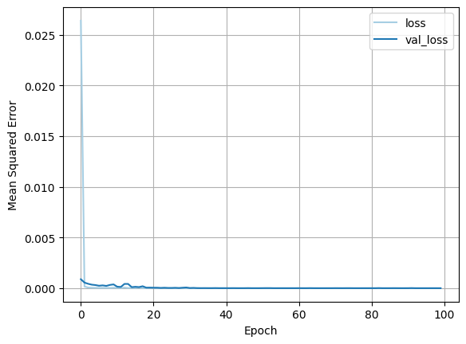

```python
def build_and_compile_model(norm):
  model = keras.Sequential([
      norm,
      layers.Dense(32, activation='relu'),
      layers.Dense(64, activation='relu'),
      layers.Dense(128, activation='relu'),
      layers.Dense(64, activation='relu'),
      layers.Dense(32, activation='relu'),
      layers.Dense(1)
  ])

  model.compile(loss='mean_squared_error',
    optimizer=tf.keras.optimizers.Adam(0.001))

  return model

dnn_model = build_and_compile_model(normalizer)
dnn_model.summary()

dnn_model_ = dnn_model.fit(
    train_features,
    train_labels,
    validation_split=0.2,
    verbose=0,
    epochs=100)

test_results['Linear_DNN'] = np.sqrt(dnn_model.evaluate(test_features, test_labels, verbose=0))

metrics_data['ModelName'].append('Linear_DNN')
metrics_data['MSE'].append(dnn_model.evaluate(test_features, test_labels['Taps_Count'], verbose=0))
metrics_data['RMSE'].append(np.sqrt(dnn_model.evaluate(test_features, test_labels['Taps_Count'], verbose=0)))

plot_loss(dnn_model_, 'Mean Squared Error')
```

```
Model: "sequential_3"
_________________________________________________________________
 Layer (type)                Output Shape              Param #
=================================================================
 normalization (Normalizatio  (None, 5)                11
 n)

 dense_8 (Dense)             (None, 32)                192

 dense_9 (Dense)             (None, 64)                2112

 dense_10 (Dense)            (None, 128)               8320

 dense_11 (Dense)            (None, 64)                8256

 dense_12 (Dense)            (None, 32)                2080

 dense_13 (Dense)            (None, 1)                 33

=================================================================
Total params: 21,004
Trainable params: 20,993
Non-trainable params: 11
_________________________________________________________________
```

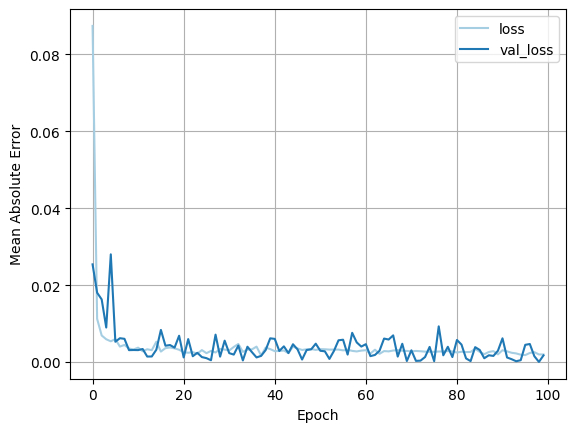

```python
def build_and_compile_model(norm):
  model = keras.Sequential([
      norm,
      layers.Dense(32, activation='relu'),
      layers.Dense(64, activation='relu'),
      layers.Dense(128, activation='relu'),
      layers.Dense(64, activation='relu'),
      layers.Dense(32, activation='relu'),
      layers.Dense(1)
  ])

  model.compile(loss='mean_absolute_error',
    optimizer=tf.keras.optimizers.Adam(0.001))

  return model

dnn_model = build_and_compile_model(normalizer)
dnn_model.summary()

dnn_model_ = dnn_model.fit(
    train_features,
    train_labels,
    validation_split=0.2,
    verbose=0,
    epochs=100)

metrics_data['MAE'].append(dnn_model.evaluate(test_features, test_labels['Taps_Count'], verbose=0))
metrics_data['AdjustedRSquared'].append(0)

plot_loss(dnn_model_, 'Mean Absolute Error')
```

## 3.4 Create the model - KNearest Regression

```
Maximum accuracy:- 1.1120953509194582 at K = 18
```

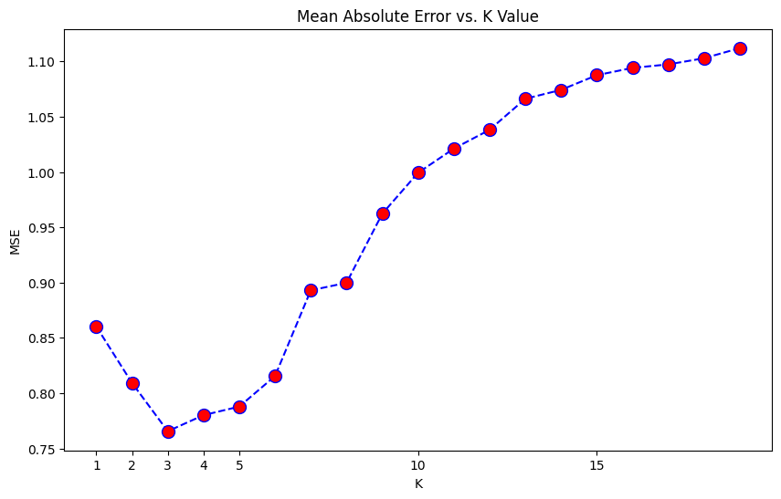

```python
train_dataset = tempWrangDF.copy()

X = train_dataset[['Contract_Type', 'Tap_Class', 'Year', 'Month']]
y = train_dataset[['Taps_Count']]

X_train, X_test, y_train, y_test = train_test_split(X, y, test_size=0.2, random_state=42)

mseList = []
# Will take some time
for i in range(1,20):
    neigh = KNeighborsRegressor(n_neighbors = i).fit(X_train, y_train)
    yhat = neigh.predict(X_test)
    mseList.append(mean_absolute_error(y_test, yhat))

plt.figure(figsize=(10,6))
plt.xticks([1,2,3,4,5,10,15,20])
plt.plot(range(1,20),mseList,color = 'blue',linestyle='dashed',
         marker='o',markerfacecolor='red', markersize=10)
plt.title('Mean Absolute Error vs. K Value')
plt.xlabel('K')
plt.ylabel('MSE')
print("Maximum accuracy:-",max(mseList),"at K =",mseList.index(max(mseList)))
```

```python
#fit the model
reg = KNeighborsRegressor(n_neighbors = 3)
knnModel = reg.fit(X_train, y_train)
knnModelPrediction = knnModel.predict(X_test)

# Evaluation
maeLog = mean_absolute_error(y_test, knnModelPrediction)
mseLog = mean_squared_error(y_test, knnModelPrediction)
rmseLog = np.sqrt(mean_squared_error(y_test, knnModelPrediction))
r2Log = r2_score(y_test, knnModelPrediction)

#Metric Logs
print('Metric Logs')
print(f'Mean absolute error: {maeLog:.3f}')
print(f'Mean squared error: {mseLog:.3f}')
print(f'Root mean squared error: {rmseLog:.2f}')
print(f'Adjusted R-Squared: {r2Log:.3f}')

test_results['KNearestRegressor = 3'] = np.sqrt(mean_squared_error(y_test, knnModelPrediction))

#Metrics Data

metrics_data['ModelName'].append('KNearestRegressor = 3')
metrics_data['MAE'].append(maeLog)
metrics_data['MSE'].append(mseLog)
metrics_data['RMSE'].append(rmseLog)
metrics_data['AdjustedRSquared'].append(r2Log)
```

```
Metric Logs
Mean absolute error: 0.766
Mean squared error: 14.451
Root mean squared error: 3.80
Adjusted R-Squared: 0.715
```

## 4. Visualize, Compare and Analyze the Results

```python
metricsDF = pd.DataFrame(metrics_data)
metricsDF
```

|  | ModelName | MAE | MSE | RMSE | AdjustedRSquared |
| --- | --- | --- | --- | --- | --- |
| 0 | XGBRegressor | 0.245038 | 0.521629 | 0.722239 | 0.987099 |
| 1 | LinearRegression | 2.118230 | 39.023988 | 6.246918 | 0.034884 |
| 2 | Linear_Neural_Networ | 0.000525 | 0.000437 | 0.020912 | 0.000000 |
| 3 | Linear_DNN | 0.002231 | 0.000438 | 0.020927 | 0.000000 |
| 4 | KNearestRegressor = 3 | 0.765523 | 14.450976 | 3.801444 | 0.714789 |

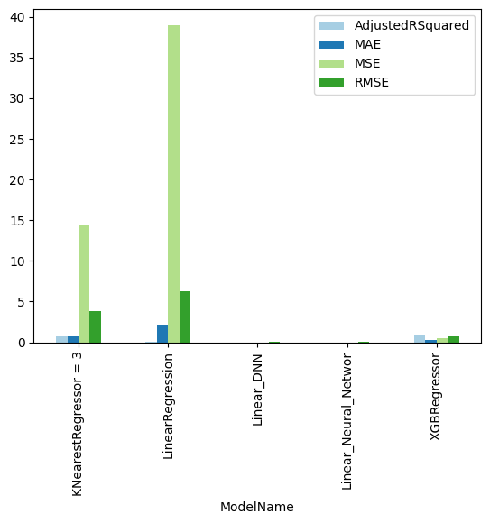

```python
metricsDF.pivot_table(index="ModelName").plot(kind='bar')
```

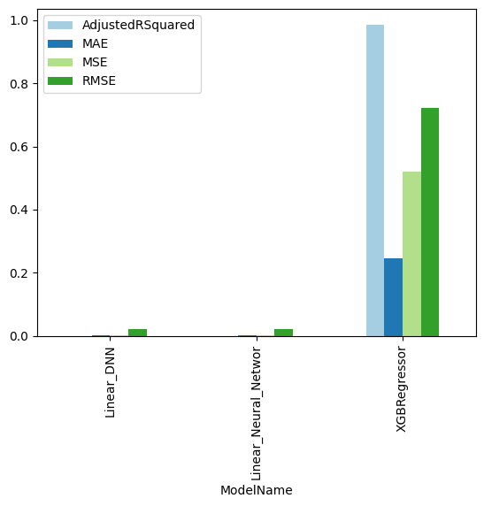

```python
_metricsDF = metricsDF.drop(index=metricsDF.index[1], axis=0)
_metricsDF = _metricsDF.drop(index=_metricsDF.index[3], axis=0)
_metricsDF.pivot_table(index="ModelName").plot(kind='bar')
```

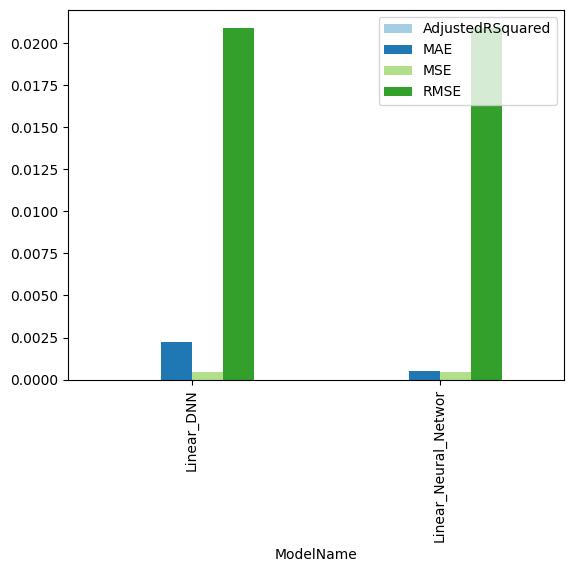

```python
_metricsDF.drop(index=metricsDF.index[0], axis=0).pivot_table(index="ModelName").plot(kind='bar')
```

### Conclusion

Model Conclusion: RMSE or Root Mean Square Error is one of the popular measure for evaludating the quality of the predictions. Thus if we checked the metrics of our generated model, we can deduce that Linear Regression with Deep Neural Network and Linear Neural Network (non-deep model) are currently the best models. During re-runs, sometimes Deep Learning has the best metric sometimes, the Neural Network has the best metric. So far, there is no way to reproduce the generated model performance into another machine but generally, they will be still performant. The amount of time to get the best parameter in neural network sometimes does not weigh the benefist. In some cases, altho neural network is a very powerful algorithm to generate a model, using an ensemble model can give us a run for our time too.

Data Conclusion: On the other hand, the dataset that was pulled from open data of NSW transporation is a relatively clean and a good dataset.